### 109-2 網絡資料分析與模式 期中考

#### 助教 杜承軒 2021.04.21

#### 一、問答題（20%）

> 1. 從 path length和clustering coefficient的觀點，說明為何人際關係是具有小世界特性的網絡結構？(10%)[10%]

```
人際關係通常滿足群聚係數(clustering coefficient)高，即常常存在同溫層，但人與人的最短距離(path length)短，如六度分隔的實驗結果所示。有一部分少數人擁有眾多朋友，能跨過群集之間的連結，使節點之間的距離縮短。因此人際關係是具有小世界特性的網絡結構。
```

> 2. 說明HITS演算法計算網絡節點的authority與hub指標數值的意義，並以「好友提名的友誼網絡（例如：由班上同學以提名法，填答同班級的好友名單）」為例，說明這兩個指標的差異。[10%]

```
權威性(authority)與樞紐性(hub)，權威性從多少(重要)節點連結到自己來估計中心程度，樞紐性估計連結出去到其他(重要)節點的程度。且高樞紐性節點指向高權威性節點，高權威性節點是由高樞紐性節點所指向的。
從好友提名的友誼網絡中，權威性高，代表越多同學認為這個人是他的朋友（表示這個人是受歡迎的）；樞紐性高，代表他認定的朋友中，有許多權威性高的人（表示這個人的朋友多是受歡迎，認定性高、很有眼光）。
```

#### 二、計算題（40%）

##### 針對下圖網絡圖，分析該網絡結構的重要特徵。

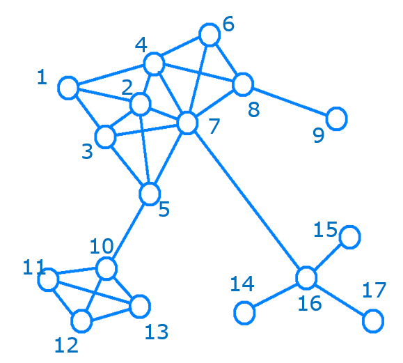

```r
library(igraph)

M=matrix(0,17,17)
M[1,2:4]=M[2,c(3:5,7)]=M[3,c(5,7)]=M[5,c(7,10)]=1
M[4,6:8]=M[6,7:8]=M[7,c(8,16)]=M[8,9]=1
M[10,11:13]=M[11,12:13]=M[12,13]=1
M[14,16]=M[15,16]=M[16,17]=1
M=M+t(M)

G=graph.adjacency(M,"undirect")
V(G)$name=1:17
```

> 1. 計算網絡整體連結性指標：Diameter與Density。[2%+3%]

```
Diameter=5，為最長的兩點最小距離，如{17,16,7,5,10,12}。
Density =「edge數E」除以「所有可能edge組合V(V-1)/2」=(28)÷(17*16/2)=7/34
```

↓程式計算

```r
sprintf("Diameter = %d, Density = %.4f",diameter(G),edge_density(G))
```

```
[1] "Diameter = 5, Density = 0.2059"
```

```r
#或
diam=1;P=M
while(any(P==0)){P=P%*%M+M;diam=diam+1}

nE=sum(M)/2 #length(E(G))
nV=nrow(M) #length(V(G))
dens=nE/(nV*(nV-1)/2)

sprintf("Diameter = %d, Density = %.4f",diam,dens)
```

```
[1] "Diameter = 5, Density = 0.2059"
```

> 2. 計算 node 2 的Clustering coefficient。[5%]

```
node2的egos網絡，alters節點數量=5，alters彼此的連線數量=6。
Clustering coefficient =「alters彼此的連線數量」除以「所有可能連線數量」=(6)÷(5*4/2)=0.6
```

↓程式計算

```r
sprintf("Clustering coefficient (node2) = %.1f",transitivity(G,"local")[2])
```

```
[1] "Clustering coefficient (node2) = 0.6"
```

```r
#或
id2=which(M[2,]==1)
M2=M[id2,id2]
G2=graph.adjacency(M2,"undirect")
dens2=sum(M2)/(nrow(M2)*(nrow(M2)-1)) #同edge_density(G2)
sprintf("Clustering coefficient (node2) = %.1f",dens2)
```

```
[1] "Clustering coefficient (node2) = 0.6"
```

> 3. 計算 node 2 的Effective Size。[5%]

```
node2的egos網絡，alters節點數量=5(Va)，alters彼此的連線數量=6(Ea)。
Effective Size = Va-Ea×2÷Va=(5)-(6)×2÷(5)=2.6
```

↓程式計算

```r
sprintf("Effective Size (node2) = %.1f",influenceR::ens(G)[2])
```

```
[1] "Effective Size (node2) = 2.6"
```

```r
#或
nE2=sum(M2)/2;nV2=nrow(M2)
sprintf("Effective Size (node2) = %.1f",nV2-nE2*2/nV2)
```

```
[1] "Effective Size (node2) = 2.6"
```

> 4. 從結構洞指標Efficiency的觀點，比較 node 2和 node 5的個體網絡（ego-network）能從網絡獲取的競爭力。[計算Efficiency 5% + 說明5%]

```
Efficiency = Effective Size ÷ ego網絡中alters節點數量
node5的egos網絡，alters節點數量=4(Va)，alters彼此的連線數量=3(Ea)。
Effective Size (node 5) = Va-Ea×2÷Va=(4)-(3)×2÷(4)=2.5
Efficiency (node 2) = 2.6/5 = 0.52
Efficiency (node 5) = 2.5/4 = 0.625
```

```
Node 5 的競爭力較大。雖然Node 2有較多連結，但資訊的來源重複，或有冗餘，且 alters 之間的都有連結；Node 5則為兩個群體之間的橋樑，雖然連結節點少，但能掌握多方訊息，在網絡中存在有結構洞。
```

↓程式計算

```r
eff=influenceR::ens(G)/degree(G)
sprintf("Efficiency: node2 = %.3f, node5 = %.3f",eff[2],eff[5])
```

```
[1] "Efficiency: node2 = 0.520, node5 = 0.625"
```

```r
#或
id5=which(M[5,]==1)
M5=M[id5,id5]
nE5=sum(M5)/2;nV5=nrow(M5)
eff5=(nV5-nE5*2/nV5)/nV5
eff2=(nV2-nE2*2/nV2)/nV2
sprintf("Efficiency: node2 = %.3f, node5 = %.3f",eff2,eff5)
```

```
[1] "Efficiency: node2 = 0.520, node5 = 0.625"
```

> 5. 計算該網絡結構中，Size最大的Clique個數，並列出這些Clique所屬的節點。[5%]

```
〇－－〇　四個節點滿足左圖才會是size=4的Clique，
｜＼／｜　因此滿足條件的有3個。
｜／＼｜　分別為：
〇－－〇　{2,3,5,7},{4,6,7,8},{10,11,12,13}
```

↓程式計算

```r
C=largest.cliques(G)
for(i in 1:3) print(C[[i]]%>%as.vector)
```

```
[1] 13 10 11 12
[1] 7 8 4 6
[1] 7 2 3 5
```

> 6. 在3-core structure的subgraph中，找出其中兩個包含有node 10的subgraph，並列出所屬的節點。[10%]

```
滿足條件的子圖有以下六種：
{10,11,12,13}                → 10~13
{10,11,12,13,2,3,5,7}        → 10~13,2,3,5,7
{10,11,12,13,2,3,5,7,1,4}    → 10~13,1~5,7
{10,11,12,13,2,4,5,6,7,8}    → 10~13,2,4~8
{10,11,12,13,2,4,5,6,7,8,3}  → 10~13,2~8
{10,11,12,13,2,4,5,6,7,8,3,1}→ 10~13,1~8
```

↓程式計算（參考）

```r
coreness(G)
```

```
 1  2  3  4  5  6  7  8  9 10 11 12 13 14 15 16 17
 3  3  3  3  3  3  3  3  1  3  3  3  3  1  1  1  1
```

#### 三、實作題（40%，每題各20%）

##### 利用load函數載入實作資料 data.Rdata，該檔案提供的網絡資料：n_f （igraph格式）

```r
load("data.RData")
```

#### （一）結構等位的實作分析

> 1.哪兩個節點之間的等位差異距離最遠（回答兩個節點名稱）？[5%]

```r
M=get.adjacency(n_f)%>%as.matrix
M.sedist=sna::sedist(M, method="euclidean")
se.id=which(M.sedist==max(M.sedist),arr.ind = TRUE)[1,]
V(n_f)$name[se.id]
```

```
[1] "John A" "Mr Hi"
```

> 2.依照等位差異分成4個模塊(block)，將等位節點以相同顏色方式呈現，繪製其網絡圖。[5%]

```r
library(concorR)
```

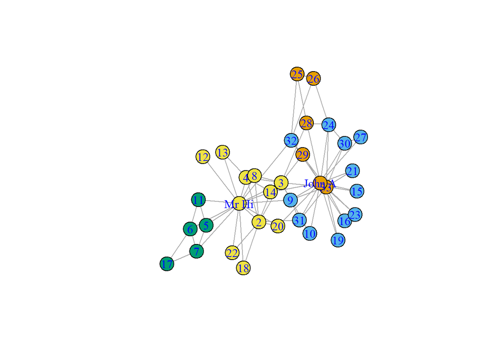

```r
LM=list(M)
CG2=concor_make_igraph(LM,2)[[1]]
V(CG2)$name[2:33]=2:33
plot(CG2, vertex.color=V(CG2)$csplit2,vertex.size=15,vertex.label.color="Blue",edge.arrow.size=0)
```

> 3.建立image matrix以及reduced graph。[5%+5%]

```r
image=make_reduced(LM, nsplit = 2)
(image_matrix=image$reduced_mat[[1]])
```

```
        Block 1 Block 2 Block 3 Block 4
Block 1       1       1       0       0
Block 2       1       0       0       0
Block 3       0       0       1       0
Block 4       0       0       0       1
```

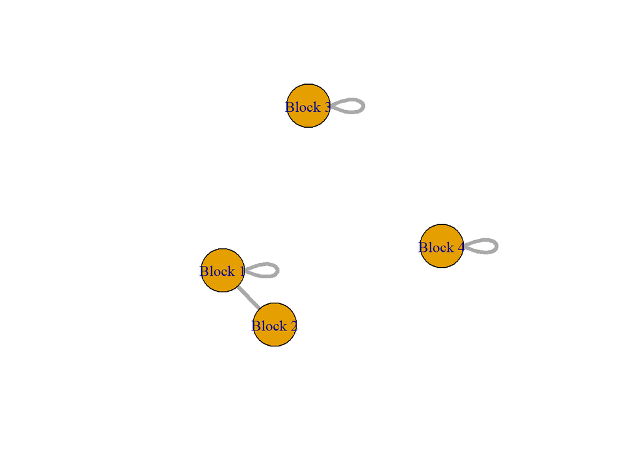

```r
reduced_graph=make_reduced_igraph(image_matrix)
plot(reduced_graph,edge.arrow.size=0,vertex.size=40,edge.width=4)
```

#### （二）個體網絡（ego-network）的實作分析

> 1.計算每個節點的網絡密度，並繪製成直方圖 (histogram)。[5%]

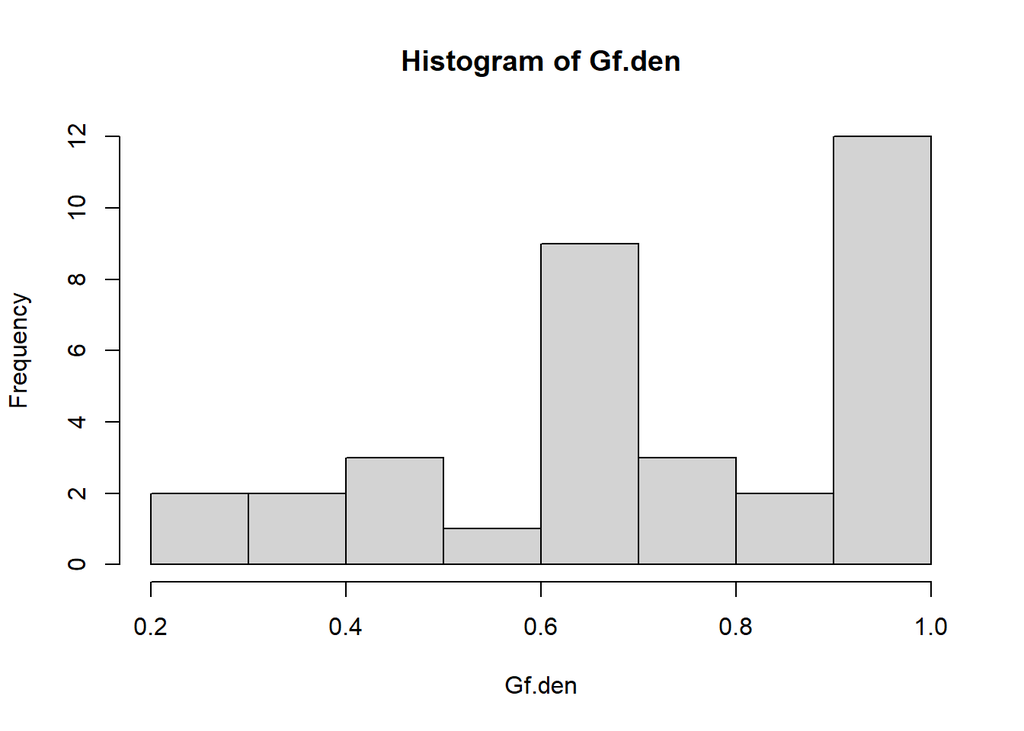

```r
egos=make_ego_graph(n_f)
Gf.den=sapply(egos, edge_density)
hist(Gf.den)
```

> 2.計算網絡節點的程度中心性(degree centrality)，並彙整前一小題的網絡密度，請繪製散布圖(scatter plot)呈現趨勢，並說明兩者間的相關性（X軸：網絡密度、Y軸：程度中心性）。[5%]

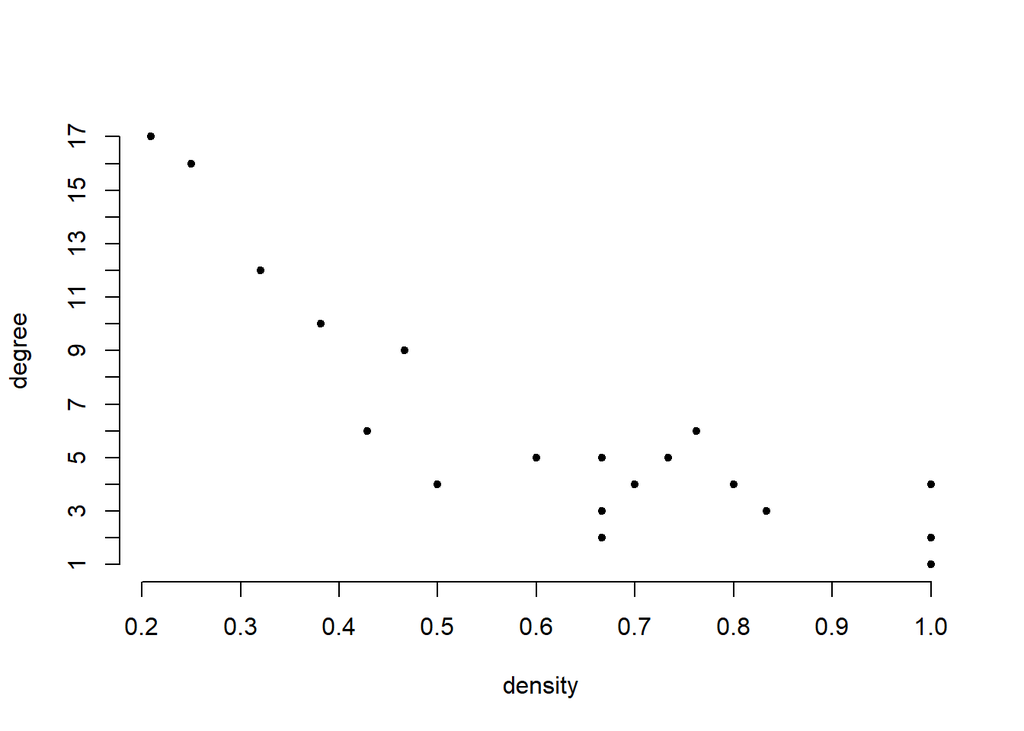

```
在此網絡中，各個個體網絡的網絡密度與程度中心性呈現負相關。
程度中心性越低，表示連結的節點較少，彼此間也可能相互認識。
程度中心性越高，表示連結的節點較多，彼此間相不直接認識的機會較大，因此密度較低。
```

```r
Gf.deg=degree(n_f)
plot(Gf.den,Gf.deg,xlab="density",ylab="degree",axes = F,pch=20)
axis(1,2:10*0.1);axis(2,1:17)
```

> 3.針對Node 34 (“John A”) 為ego的個體網絡，以節點屬性age (C: child; A: adult, E: elder)，用 E-I index 比較中心節點(ego)和alters的屬性相似性(homophily)，並將計算結果的數值進行說明。[10%]

```r
Ge=egos[[34]]
ext=sum(V(Ge)$age!=V(Ge)["John A"]$age)
int=sum(V(Ge)$age==V(Ge)["John A"]$age)-1
EI=(ext-int)/(ext+int)
sprintf("John A個體網絡的中心節點E-I指數 = %.4f",EI)
```

```
[1] "John A個體網絡的中心節點E-I指數 = 0.1765"
```

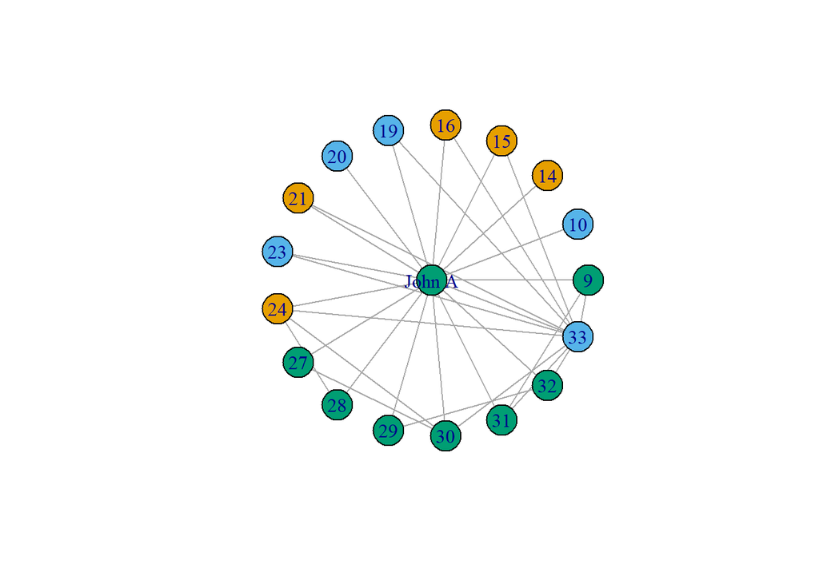

```
相連節點中，與中心網絡age性質不同的節點數：10
相連節點中，與中心網絡age性質相同的節點數：7
E-I指數(針對節點)=(10-7)/(10+7)=3/17=0.1765
E-I指數大於0，表示周圍節點與中心節點的屬性多為不同。
E-I指數越大（正數，越接近1），同質性(homophily)越低；E-I指數越小（負數，越接近-1），同質性(homophily)越高。
John A個體網絡的中心節點E-I指數=0.1765，表示周圍節點的年齡層與John A自己較不像。
```

```r
V(Ge)$name=gsub("Actor ","",V(Ge)$name)
plot(Ge,vertex.color=factor(V(Ge)$age),vertex.size=20,layout=layout_as_star(Ge,V(Ge)["John A"]))
```